# Reproducible Research: Peer Assessment 1

Corbin Thornbrough

Sunday, August 17th, 2014

## Loading and preprocessing the data

#### The following code unzips the activity csv and reads it into R as the “activity” table.

```r
setwd("C:/Users/corbin.thornbrough/Documents/GitHub/RepData_PeerAssessment1")
unzip("activity.zip")
activity<-read.csv("activity.csv")
options(scipen=4)
```

#### This code transforms the data types to make the data more usable.

```r
activity$date<-as.Date(activity$date)
activity$steps<-as.numeric(activity$steps)
activity$interval<-as.numeric(activity$interval)
options(scipen=4)
```

## What is mean total number of steps taken per day?

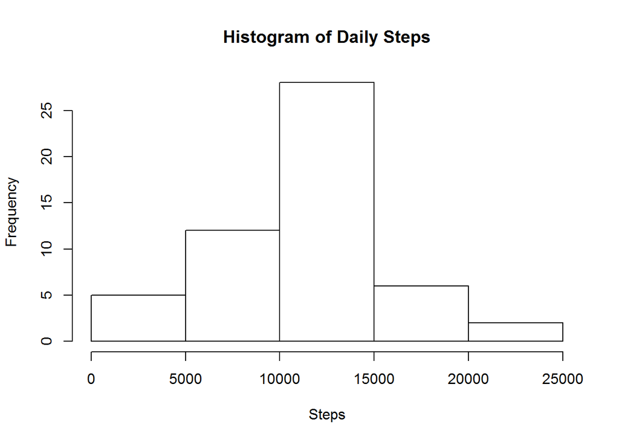

The mean number of steps by day is 10766.1887 while the median is 10765.

## What is the average daily activity pattern?

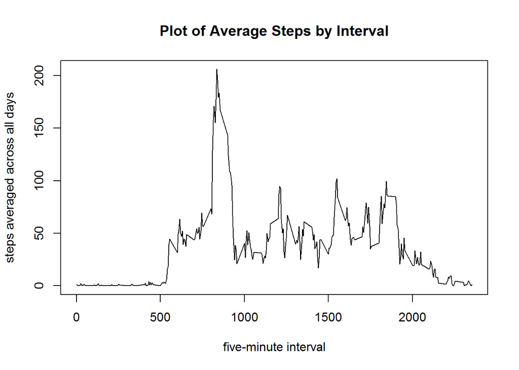

The 835 interval is the interval with the largest average number of steps.

## Imputing missing values

There are 2304 missing values in the dataset.

#### This creates a new dataset with NA values (for the steps variable) replaced by the mean number of steps for that interval over the week.

```r
activity.mod<-activity
activity.mod$steps<-with(activity.mod,ifelse(
  is.na(steps),
  ave(steps,interval,FUN=function(steps)mean(steps, na.rm=TRUE)),
  steps
  ))
```

#### Here is a histogram of the total number of steps taken each day with the NAs replaced.

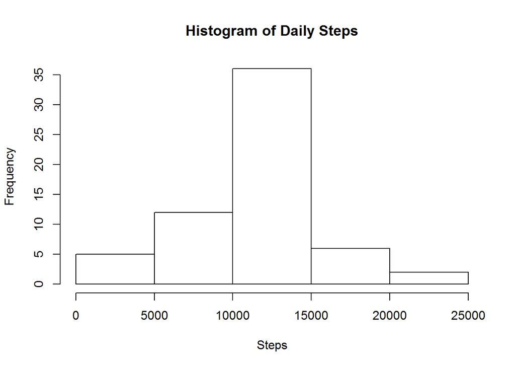

## Are there differences in activity patterns between weekdays and weekends?

#### This adds another variable to the dataset with NAs replaced. This new variable denotes that the record was on a weekend (Saturday & Sunday) or a weekend (Monday-Friday).

```r
activity.mod$weekday<-ifelse(weekdays(activity.mod$date)=="Saturday" | weekdays(activity.mod$date)=="Sunday","weekend","weekday")
```

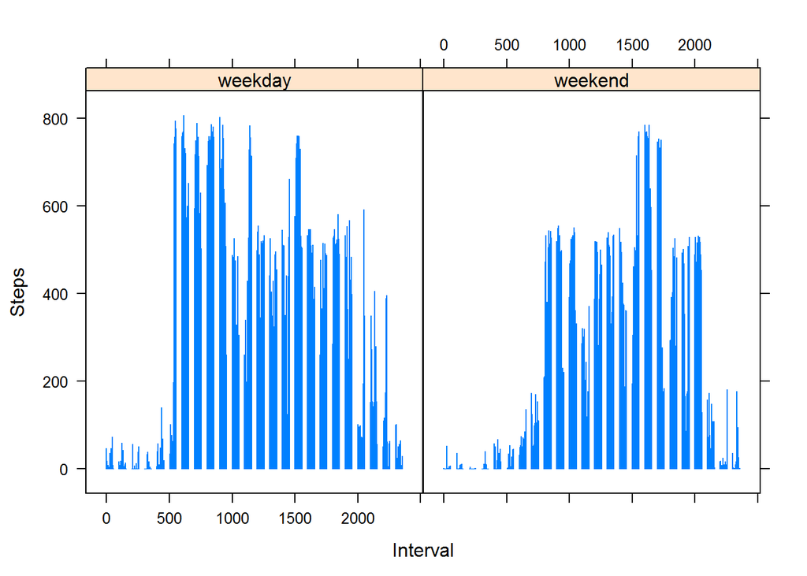

As you can see, on the weekends, activity begins much later in the day and extends further into the evening than on the weekdays.